# Analysis of Diversity Outbred mouse data

Karl W Broman

2023-06-07

Here we consider the data from [Al-Barghouthi et al. (2021)](https://doi.org/10.1038/s41467-021-23649-0) on Diversity Outbred mouse data, and compare the use of an exact hidden Markov model (HMM) to a more approximate one. The data are available at [zenodo](https://doi.org/10.5281/zenodo.4265417), and analysis scripts are at [github](https://github.com/basel-maher/DO_project) as well as archived at [zenodo](https://doi.org/10.5281/zenodo.4718146).

### Load packages and data

We first load [R/qtl2](https://kbroman.org/qtl2) as well as the qtl2convert, qtl2fst, broman, and [here](https://here.r-lib.org) packages.

```r
library(qtl2)
library(qtl2convert)
library(broman)
library(here)
library(qtl2fst)
```

We create a cache directory to store stuff.

```r
cachedir <- here("DOapp/_cache")
if(!dir.exists(cachedir)) dir.create(cachedir)
```

We download the data from the [zenodo](https://doi.org/10.5281/zenodo.4265417) and load it; the `.RData` file contains a single object `cross_basic`.

```r
url <- "https://zenodo.org/record/4265417/files/cross_basic_cleaned.Rdata"
file <- file.path(cachedir, basename(url))
if(!file.exists(file)) download.file(url, file)
load(file)
```

The data concern 619 Diversity Outbred mice (from generations 23 – 33), including 304 females and 315 males. They were genotyped with the GigaMUGA array. There are a total of 109,427 informative markers.

We create a `"genail"` version, to use the general (but approximate) HMM.

```r
genail <- qtl2convert::cross2_do_to_genail8(cross_basic)
```

### Calculate genotype probabilities

We insert pseudomarkers into the marker so that no two markers/pseudomarkers are > 0.1 cM apart. We use interpolation to find the corresponding physical positions.

```r
gmap <- insert_pseudomarkers(cross_basic$gmap, step=0.1, stepwidth="max")
pmap <- interp_map(gmap, cross_basic$gmap, cross_basic$pmap)
```

Now we do the genome reconstruction, first with the more “exact” HMM. We assume 0.2% genotyping error and use the [Carter-Falconer map function](https://www.ias.ac.in/article/fulltext/jgen/050/02/0307-0323).

The results are enormous, so here we will use qtl2fst to save memory, calculating them but storing them on disk.

```r
dir <- file.path(cachedir, "probs_do")
if(!dir.exists(dir)) dir.create(dir)

fpr_do <- calc_genoprob_fst(cross_basic, "probs_do", dir,
                            gmap, error_prob=0.002,
                            map_function="c-f", cores=0)
```

We will also convert them to allele dosages, again using the qtl2fst package to save them on disk.

```r
dir <- file.path(cachedir, "aprobs_do")
if(!dir.exists(dir)) dir.create(dir)
fapr_do <- genoprob_to_alleleprob_fst(fpr_do, "aprobs_do", dir, cores=0)
```

We now do the same thing using the `"genail8"` cross type that gives the approximate HMM. First the 36-state genotype probabilities.

```r
dir <- file.path(cachedir, "probs_genail")
if(!dir.exists(dir)) dir.create(dir)

fpr_genail <- calc_genoprob_fst(genail, "probs_genail", dir,
                                gmap, error_prob=0.002,
                                map_function="c-f", cores=0)
```

We will also convert them to allele dosages, again using the qtl2fst package to save them on disk.

```r
dir <- file.path(cachedir, "aprobs_genail")
if(!dir.exists(dir)) dir.create(dir)
fapr_genail <- genoprob_to_alleleprob_fst(fpr_genail, "aprobs_genail",
                                          dir, cores=0)
```

Note that when I calculated the genotype probabilities directly (without using the qtl2fst package) using an 8-core linux laptop with 64 GB RAM, it took 2100 sec with the `"do"` cross type and 1594 sec with the `"genail8"` cross type, so the approximate method took about 75% as much time.

## Genome scans for QTL

We’ll now perform genome scans to see how the results compare. We’ll use a linear mixed model, with a random polygenic effect to account for relationships, using the “leave-one-chromosome-out” (LOCO) method.

So first we calculate the kinship matrices.

```r
k_do <- calc_kinship(fapr_do, "loco", cores=0)
k_genail <- calc_kinship(fapr_genail, "loco", cores=0)
```

```r
kfile_do <- file.path(cachedir, "kinship_loco_do.rds")
kfile_genail <- file.path(cachedir, "kinship_loco_genail.rds")
if(file.exists(kfile_do) && file.exists(kfile_genail)) {
    k_do <- readRDS(kfile_do)
    k_genail <- readRDS(kfile_genail)
} else {
k_do <- calc_kinship(fapr_do, "loco", cores=0)
k_genail <- calc_kinship(fapr_genail, "loco", cores=0)
    saveRDS(k_do, kfile_do)
    saveRDS(k_genail, kfile_genail)
}
```

We set up some covariates to use; see the [`map_qtl.R`](https://github.com/basel-maher/DO_project/blob/master/src/map_qtl.R) file in the [code repository](https://github.com/basel-maher/DO_project/) for the [Al-Barghouthi et al. (2021)](https://doi.org/10.1038/s41467-021-23649-0) paper.

```r
covar <- as.matrix(cross_basic$covar)
covar[,"sex"] <- (covar[,"sex"] == "M")*1
covar <- covar[,!(colnames(covar) %in% c("sac_date", "body_length", "ngen"))]
covar <- apply(covar,2,as.numeric)
rownames(covar) <- rownames(cross_basic$covar)
```

And now we perform the genome scans for a set of selected phenotypes. For most of them, we take logs; for Wpy we take log(x+1); and there are a set of 6 that we leave untransformed.

```r
qcol <- c(TMD="uCT_Ct.TMD",
          Ma.Ar="uCT_Ma.Ar",
          Tt.Ar="uCT_Tt.Ar",
          Ct.Por="uCT_Ct.porosity",
          ML="ML",
          pMOI="uCT_pMOI",
          "Ct.Ar/Tt.Ar"="uCT_Ct.Ar.Tt.Ar",
          Imax="uCT_Imax",
          BMD="uCT_BMD",
          W="bending_work_to_yield",
          Wpy="bending_work_post_yield",
          Dfx="bending_disp_at_frax",
          DFmax="bending_disp_at_max_load",
          Fmax="bending_max_load",
          Ffx="bending_frax_load",
          Ct.Ar="uCT_Ct.Ar",
          Imin="uCT_Imin",
          Ct.Th="uCT_Ct.Th",
          Tb.Sp="uCT_Tb.Sp",
          Tb.N="uCT_Tb.N")

# note that uCT_Ct.porosity has a huge batch effect
# (first three batches have values < 0.5; last 8 have values > 0.5)

# phenotypes to transform (see https://github.com/basel-maher/DO_project/blob/master/src/map_qtl.R#L73-L75)
take_logp1 <- qcol["Wpy"]
take_log <- pheno_names(cross_basic)[c(6:14,16,17,21,23:33,34,35,37:41,43:49,51,52,54:58,61:70,72,74,76)] %win%
                (qcol %wnin% take_logp1)
no_log <- pheno_names(cross_basic)[c(15,18,19,20,22,36,42,50,53,59,60)] %win% qcol

# double-check that I got them all
stopifnot(length(take_logp1) + length(no_log) + length(take_log) == length(qcol))

# pull out and transform the phenotypes
phe <- cross_basic$pheno[,qcol]
phe[,take_log] <- log(phe[,take_log])
phe[,take_logp1] <- log(phe[,take_logp1] + 1)

# change the column names
colnames(phe) <- names(qcol)
```

Now, to perform the genome scans.

```r
out_scan1_do <- scan1(fapr_do, phe, k_do, addcovar=covar, cores=0)
out_scan1_genail <- scan1(fapr_genail, phe, k_genail, addcovar=covar, cores=0)
```

## Comparisons

The genotype probabilities can hardly be distinguished.

```r
p_d <- sapply(names(fpr_do), function(chr) max(abs(fpr_do[[chr]] - fpr_genail[[chr]])))
```

The maximum difference was 0.011 on the X chromosome followed by a difference of 0.0066 on chromosome 8. For that reason, the QTL mapping results were hardly different. Across all 20 traits considered, the maximum difference in LOD scores in the two sets of results was 0.020.

Here’s a plot of the LOD curves across the genome for tissue mineral density (TMD). The differences are too small to be distinguished by eye.

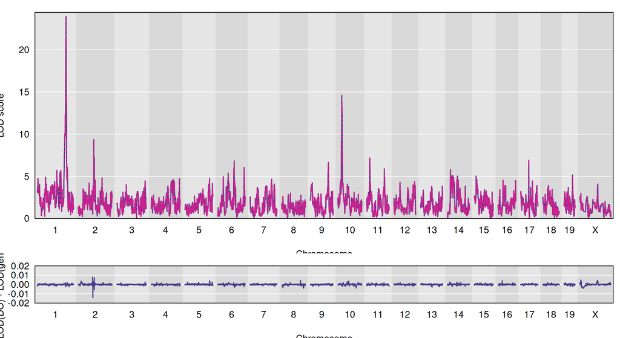

```r
layout(rbind(1,2), height=c(3,1))
par(mar=c(3.1, 3.1, 1.1, 0.6))
plot(out_scan1_do, pmap, lod="TMD")
plot(out_scan1_genail, pmap, lod="TMD", add=TRUE, col="violetred", lty=3)
plot(out_scan1_do - out_scan1_genail, pmap, ylim=c(-0.02, 0.02), lod="TMD",
     ylab="LOD(DO) - LOD(genAIL8)")
```